# Exercise 3_2: Extracting and Analyzing Raster Information

Advanced Geospatial Data Processing for Social Scientists

Author

Dennis Abel & Stefan Jünger

In this set of exercises, you’ll practice two core raster workflows:

1. **Extracting** raster values at point locations — both directly and using spatial buffers.
2. **Smoothing** raster data with `terra::focal()` and comparing the effect of different window sizes.

You’ll work with Census 2022 rasters from `./data/z22/`. Not sure what a file contains? File names match Census variable names — check the [Census 2022 database](https://ergebnisse.zensus2022.de/datenbank/online/themes) for documentation, or use `z22::z22_features()` if you have the [`z22` package](https://cran.r-project.org/package=z22) installed.

### Exercises

**Note🏋️ Exercise 1: Extraction — points and buffers**

Load the synthetic survey coordinates (`synthetic_survey_geocoordinates.rds` in `./data/survey/`) and a raster `.tif` of your choice from `./data/z22/`. Before extracting, confirm that their CRS match.

Then:

1. **Extract** raster values directly at the point locations.
2. **Create 5 km buffers** around each point and extract the **mean** raster value within each buffer.
3. **Compare** the two results: How much do the point values and the buffer means differ? Why might they differ?

**Caution💡 Tip**

- Use `readRDS()` for the points, `terra::rast()` for the raster.
- Check the CRS with `sf::st_crs()` and `terra::crs(..., describe = TRUE)`.
- `terra::extract(raster, points, ID = FALSE)` gives you 1:1 values.
- `sf::st_buffer(points, 5000)` creates 5 km buffers (units are meters in EPSG:3035).
- `terra::extract(raster, buffers, fun = mean, na.rm = TRUE)` summarizes within each buffer.

**Note🏋️ Exercise 2: Smoothing and heatmaps**

Choose a raster from `./data/z22/` and crop it to a region of interest (e.g., Berlin or any state — use the boundaries in `./data/boundaries/`).

Then:

1. **Smooth** the cropped raster with `terra::focal()` using two different window sizes (e.g., 3×3 and 9×9).
2. **Plot** the raw raster and both smoothed versions side by side. What spatial patterns become visible? At what point do you lose too much detail?
3. **Bonus:** Extract values at the survey coordinates from both the raw and the smoothed raster. How much do they differ?

**Caution💡 Tip**

- Subset a district with `dplyr::filter()`, then `terra::mask()` and `terra::crop()`.
- `terra::focal(raster, w = matrix(1, 3, 3), fun = mean, na.rm = TRUE)` applies a 3×3 moving average.
- Use `par(mfrow = c(1, 3))` to plot three maps side by side.
- For the bonus: extract from both the raw and smoothed raster and compare with `head()` or `summary()`.

### Solutions

**Tip✅ Solution 1**

```r
library(terra)
# Load data
coordinates <- readRDS("./data/survey/synthetic_survey_geocoordinates.rds")
rent_avg <- terra::rast("./data/z22/rent_avg.tif")

# Always check: do the CRS match?
sf::st_crs(coordinates)$epsg
```

```
[1] 3035
```

```r
terra::crs(rent_avg, describe = TRUE)$code
```

```
[1] "3035"
```

```r
# Both EPSG:3035 — good to go.

# --- Point extraction (1:1) ---
rent_at_points <- terra::extract(rent_avg, coordinates, ID = FALSE)
head(rent_at_points)
```

```
  cat_0
1  5.96
2  5.42
3  5.61
4  9.52
5  6.81
6  5.85
```

```r
# --- Buffer extraction (5 km neighborhood mean) ---
buffers <- sf::st_buffer(coordinates, 5000) # 5 km radius
rent_in_buffers <- terra::extract(rent_avg, buffers, fun = mean, na.rm = TRUE)
head(rent_in_buffers)
```

```
  ID    cat_0
1  1 5.590227
2  2 5.611912
3  3 5.684154
4  4 8.734386
5  5 7.676111
6  6 5.293714
```

```r
# --- Compare ---
# Point values are single-cell readings; buffer values are local averages.
# Buffer values should be less extreme (smoothed towards the neighborhood).
comparison <- data.frame(
  point  = rent_at_points[[1]],
  buffer = rent_in_buffers[[2]]
)
comparison$diff <- comparison$point - comparison$buffer

summary(comparison$diff)
```

```
    Min.  1st Qu.   Median     Mean  3rd Qu.     Max.      NAs
-2.28709 -0.33877  0.07200  0.07962  0.46552  4.19833       13
```

```r
# Positive diff = point is above its neighborhood; negative = below.
```

**Tip✅ Solution 2**

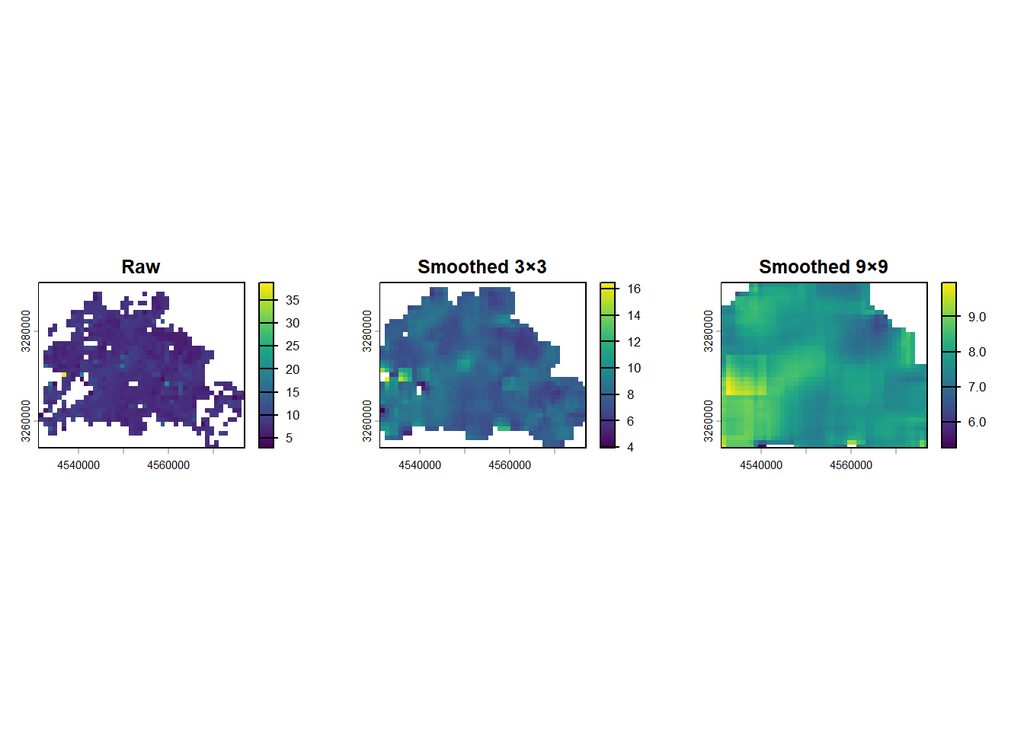

```r
library(terra)

# --- Subset to Berlin ---
german_districts <-
  sf::st_read("./data/boundaries/VG250_KRS.shp", quiet = TRUE) |>
  sf::st_transform(3035)

berlin <- german_districts |> dplyr::filter(AGS == "11000")

rent_berlin <-
  terra::rast("./data/z22/rent_avg.tif") |>
  terra::project("EPSG:3035") |>
  terra::mask(berlin) |>
  terra::crop(berlin)

# --- Smooth with two window sizes ---
rent_3x3 <- terra::focal(rent_berlin, w = matrix(1, 3, 3), fun = mean, na.rm = TRUE)
rent_9x9 <- terra::focal(rent_berlin, w = matrix(1, 9, 9), fun = mean, na.rm = TRUE)

# --- Side-by-side comparison ---
par(mfrow = c(1, 3))
plot(rent_berlin, main = "Raw")
plot(rent_3x3, main = "Smoothed 3×3")
plot(rent_9x9, main = "Smoothed 9×9")
```

```r
par(mfrow = c(1, 1))
# The 3×3 reveals clusters while keeping local variation.
# The 9×9 is much smoother — good for broad trends, but fine detail is lost.

# --- Bonus: compare extracted values ---
coords_berlin <- sf::st_crop(coordinates, berlin)
raw_vals <- terra::extract(rent_berlin, coords_berlin, ID = FALSE)[[1]]
smooth_vals <- terra::extract(rent_9x9, coords_berlin, ID = FALSE)[[1]]

summary(raw_vals - smooth_vals)
```

```
   Min. 1st Qu.  Median    Mean 3rd Qu.    Max.     NAs
-0.8927 -0.6892 -0.4723 -0.3559 -0.1764  1.3478       3
```

```r
# Differences show how much local noise is removed by smoothing.
```